# Predicting Weight Lifting Exercises

Mark Kiel

2020-12-11

```r
library(caret)
library(randomForest)
training <- read.csv("pml-training.csv", header=T)
testing <- read.csv("pml-testing.csv", header=T)
seed <- 332
```

### Data Exploration

```r
sumMissing <- sapply(training, function(x) sum(is.na(x)))
colsMissing <- names(training[sumMissing > 0])
indexMissing <- which(names(training) %in% colsMissing)
table(sumMissing, dnn=c("Features missing 0 or 19216 values"))
```

```
## Features missing 0 or 19216 values
##     0 19216
##    93    67
```

```r
rowCompleteClass <- training[complete.cases(training), "classe"]
table(rowCompleteClass, dnn="Class results of complete rows")
```

```
## Class results of complete rows
##   A   B   C   D   E
## 109  79  70  69  79
```

```r
rowIncompleteClass <- training[!complete.cases(training), "classe"]
table(rowIncompleteClass, dnn="Class results of incomplete rows")
```

```
## Class results of incomplete rows
##    A    B    C    D    E
## 5471 3718 3352 3147 3528
```

```r
new_train <- training[-c(1:7, 160, indexMissing)] # 75 features removed
new_test  <- testing[-c(1:7, 160, indexMissing)]
```

There are 67 columns with missing values and each has exactly 19,216 of these. Looking at the class results for those rows that are complete and incomplete, there doesn't seem to be a meaningful difference in proportions. Therefore, removing the features with missing values should not have a large impact on the model performance.

```r
nz <- which(nearZeroVar(new_train, saveMetrics=T)$nzv == TRUE)
c("Features with near-zero variance"=length(nz))
```

```
## Features with near-zero variance
##                               33
```

```r
new_train <- new_train[-c(nz)]
new_test <- new_test[-c(nz)]
```

More features could be removed by checking those with a variance near zero. These would likely not improve the model much as they wouldn't contribute enough information to affect the classification of the training data. Removing these features may also speed up the model fitting process, though it has not been tested in this report.

With the large number of features in the data set and the need for a classifier prediction, a random forest model should work well. Three different random forest models were created, using different functions and hyperparameters.

### Model 1 : Random Forest with Out-of-bag error

```r
set.seed(seed)
rf1 <- randomForest(new_train, training$classe, importance=T)
rf1
```

```
##
## Call:
##  randomForest(x = new_train, y = training$classe, importance = T)
##                Type of random forest: classification
##                      Number of trees: 500
## No. of variables tried at each split: 7
##
##         OOB estimate of  error rate: 0.29%
## Confusion matrix:
##      A    B    C    D    E  class.error
## A 5578    1    0    0    1 0.0003584229
## B   13 3781    3    0    0 0.0042138530
## C    0   10 3410    2    0 0.0035067212
## D    0    0   18 3196    2 0.0062189055
## E    0    0    2    4 3601 0.0016634322
```

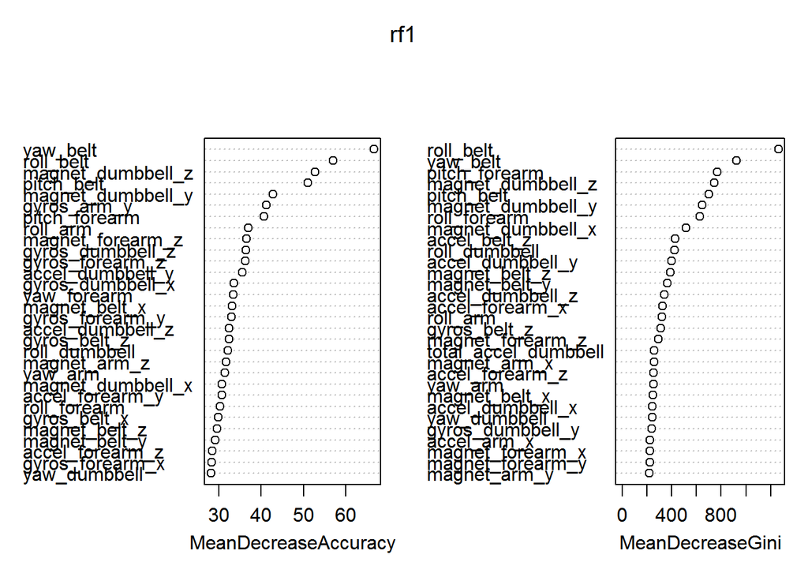

```r
imp <- sort(importance(rf1)[,"MeanDecreaseAccuracy"], decreasing=T)
varImpPlot(rf1)
```

```r
indexImp <- which(names(new_train) %in% names(imp[1:24]))
```

The first model uses a forest of 500 trees and splits on 7 variables at each branch of the tree. The accuracy is over 99% with class A almost predicted perfectly. The variable importance is displayed in a plot showing which features will decrease the accuracy the most if omitted from the model. For the next model only the most important 24 features will be used for prediction.

### Model 2: Random Forest using 10-fold cross validation and reduced features

```r
set.seed(seed)
model2_train <- new_train[,c(indexImp)]
control <- trainControl(method="cv", number=10, search="random")
rf2 <- train(model2_train, training$classe, method="rf", metric="Accuracy",
             tuneLength=10, trControl=control, ntree=100)
confusionMatrix(rf2)
```

```
## Cross-Validated (10 fold) Confusion Matrix
##
## (entries are percentual average cell counts across resamples)
##
##           Reference
## Prediction    A    B    C    D    E
##          A 28.4  0.1  0.0  0.0  0.0
##          B  0.0 19.2  0.1  0.0  0.0
##          C  0.0  0.1 17.4  0.1  0.0
##          D  0.0  0.0  0.0 16.3  0.0
##          E  0.0  0.0  0.0  0.0 18.3
##
##  Accuracy (average) : 0.9958
```

### Model 3: Random Forest using the Ranger implementation

```r
library(ranger)
rf3 <- ranger(training$classe ~ ., data=new_train, importance="impurity",
             num.trees=1000, seed=seed, write.forest=TRUE, verbose=F)
rf3
```

```
## Ranger result
##
## Call:
##  ranger(training$classe ~ ., data = new_train, importance = "impurity",      num.trees = 1000, seed = seed, write.forest = TRUE, verbose = F)
##
## Type:                             Classification
## Number of trees:                  1000
## Sample size:                      19622
## Number of independent variables:  52
## Mtry:                             7
## Target node size:                 1
## Variable importance mode:         impurity
## OOB prediction error:             0.31 %
```

```r
rf3$confusion.matrix
```

```
##     predicted
## true    A    B    C    D    E
##    1 5577    2    0    0    1
##    2    9 3784    4    0    0
##    3    0   11 3408    3    0
##    4    0    0   19 3192    5
##    5    0    0    1    5 3601
```

The final model uses the Ranger implementation of the Random Forest classifier. Since this method performs faster during model fitting, 1000 trees were used during classification. Again, the results were almost the same with almost perfect prediction on class A.

### Predictions

```r
predict(rf1, new_test)
```

```
##  1  2  3  4  5  6  7  8  9 10 11 12 13 14 15 16 17 18 19 20
##  B  A  B  A  A  E  D  B  A  A  B  C  B  A  E  E  A  B  B  B
## Levels: A B C D E
```

```r
predict(rf2, new_test)
```

```
##  [1] B A B A A E D B A A B C B A E E A B B B
## Levels: A B C D E
```

```r
predict(rf3, new_test)$predictions
```

```
##  [1] B A B A A E D B A A B C B A E E A B B B
## Levels: A B C D E
```

Each model correctly predicted the exercise class for each individual sample in the test data set, according to the project quiz. Of course, additonal test data would be needed to confirm the existence of model over-fitting. However, only these 20 test samples were provided.